# 2018-02-12 pNF Drug Screening tSNE Target Clusters

Then, we take the binarized target matrix (`target_data_filt`) and use t-SNE (`Rtsne`) to see if there are any clusters of drugs based on their binarized target information. We’ll try this for a range of perplexities and pick the one that seems to contain the most stable clusters across multiple perplexities.

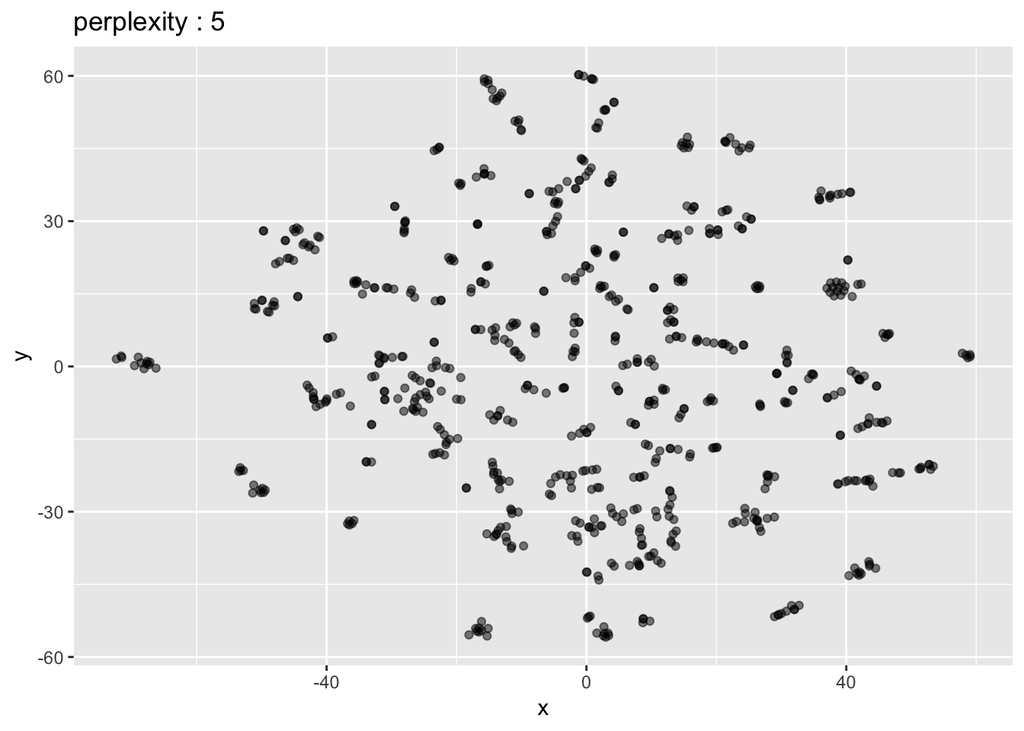

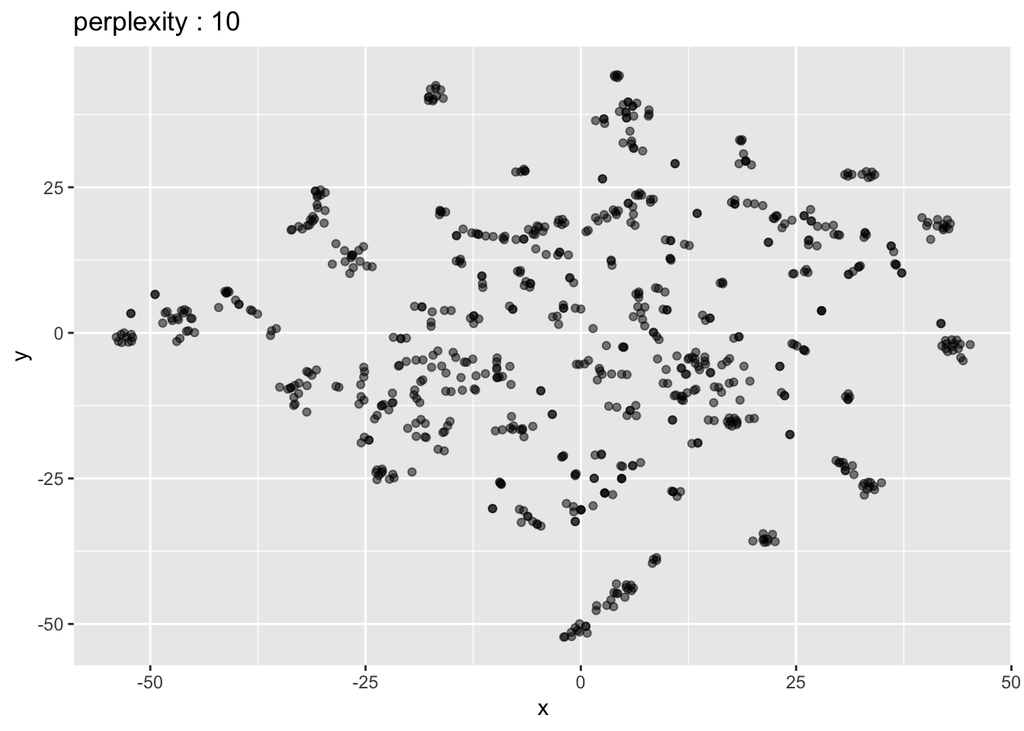

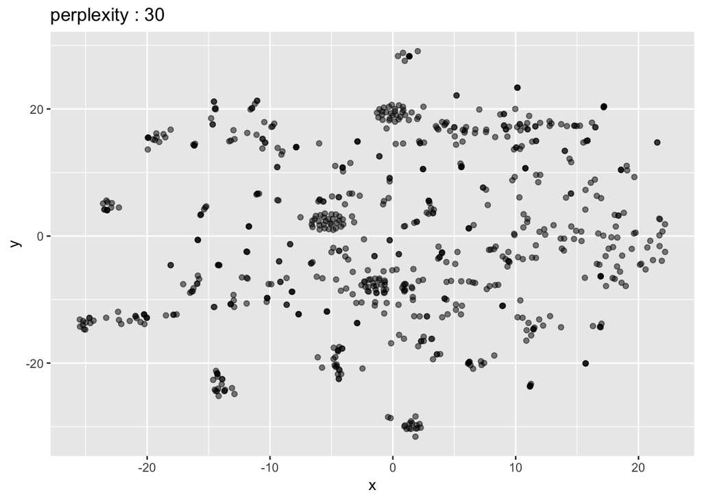

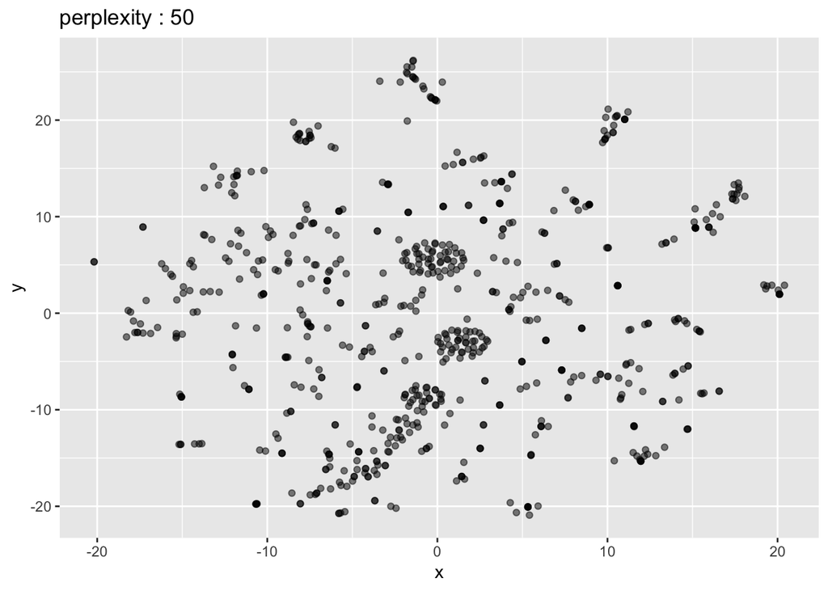

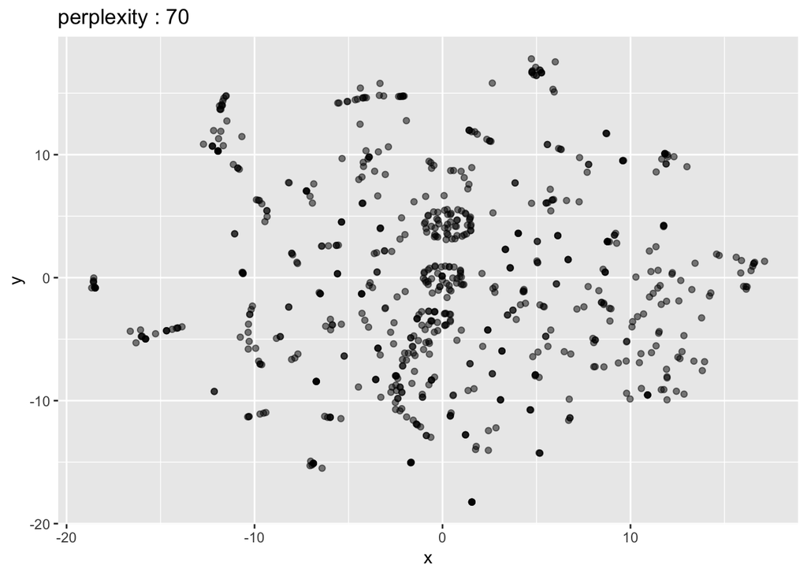

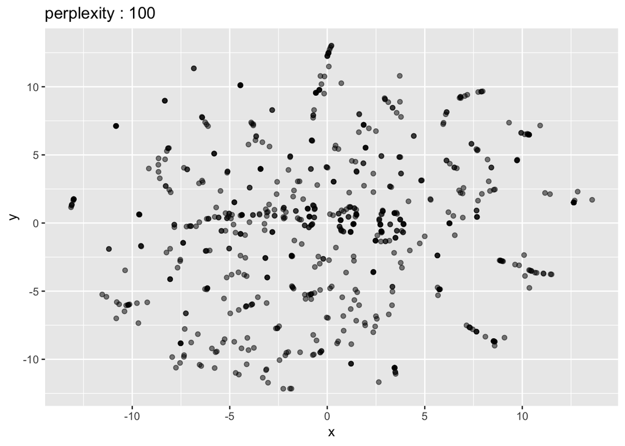

```r
library(Rtsne)

perplexities <- c(5,10,30,50,70,100)

for(i in perplexities){
foo <- Rtsne(target_data_filt, check_duplicates = F, perplexity = i)

foo2 <- foo$Y %>%
  as.data.frame() %>%
  add_column("DT_explorer_internal_id" = as.integer(rownames(target_data_filt))) %>%
  left_join(drug_data_filt) %>%
  left_join(distinct(select(targets, internal_id, std_name)), by = c("DT_explorer_internal_id" = "internal_id"))

p<-ggplot(foo2) +
  geom_point(aes(x = V1, y = V2), alpha = 0.5) +
  labs(x = "x", y = "y", title = paste0("perplexity : ", i))

print(p)
}
```

It looks like a perplexity of 30 captures several clusters stable across other perplexity values, so we’ll use that for the remaining analysis. To read more about tSNE, check out [this post](https://distill.pub/2016/misread-tsne/).

Now, we’ll take the tSNE output, and map it back to the median IC50s to add another dimension of information to our plots.

```r
foo <- Rtsne(target_data_filt, check_duplicates = F, perplexity = 30)

foo2 <- foo$Y %>% as.data.frame() %>% add_column("DT_explorer_internal_id" = as.integer(rownames(target_data_filt))) %>% left_join(drug_data_filt) %>% left_join(distinct(select(targets, internal_id, std_name)), by = c("DT_explorer_internal_id" = "internal_id"))
```

This is what the plain plot looks like. Several clusters pop out that might indicate families of drugs with similar target profiles.

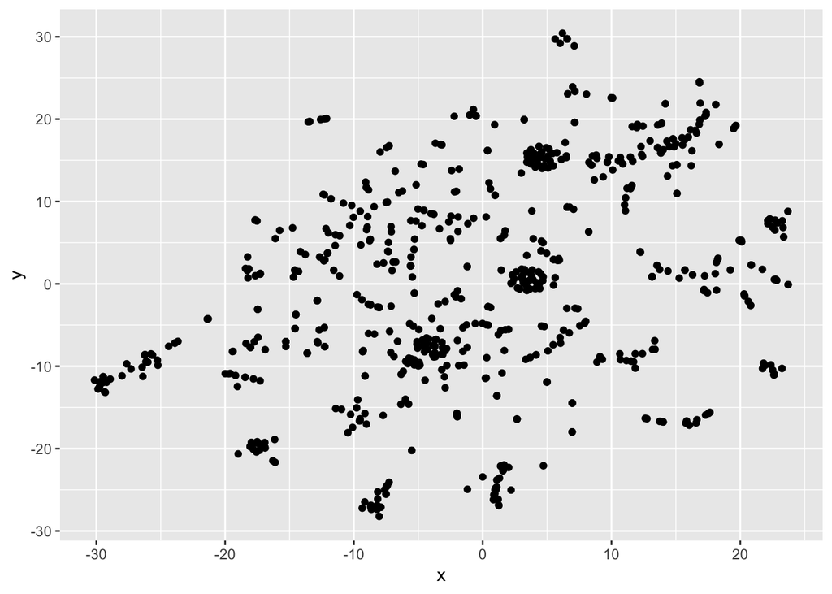

```r
p <- ggplot(foo2) +
  geom_point(aes(x = V1, y = V2)) +
  labs(x = "x", y = "y")

print(p)
```

We’ll add the response information - log(IC50) where darker points have a better response. Several drug clusters have lots of dark points. These might be interesting to evaluate further!

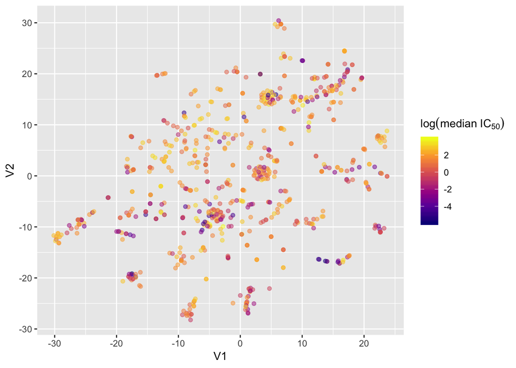

```r
ggplot(foo2) +
  geom_point(aes(x = V1, y = V2, color = log(median_response)), alpha = 0.5) +
  scale_color_viridis_c(option = "C", name = expression(log(median~IC['50'])))
```

Let’s add labels for compounds where the median IC50 is less than 0.05 uM (50 nM).

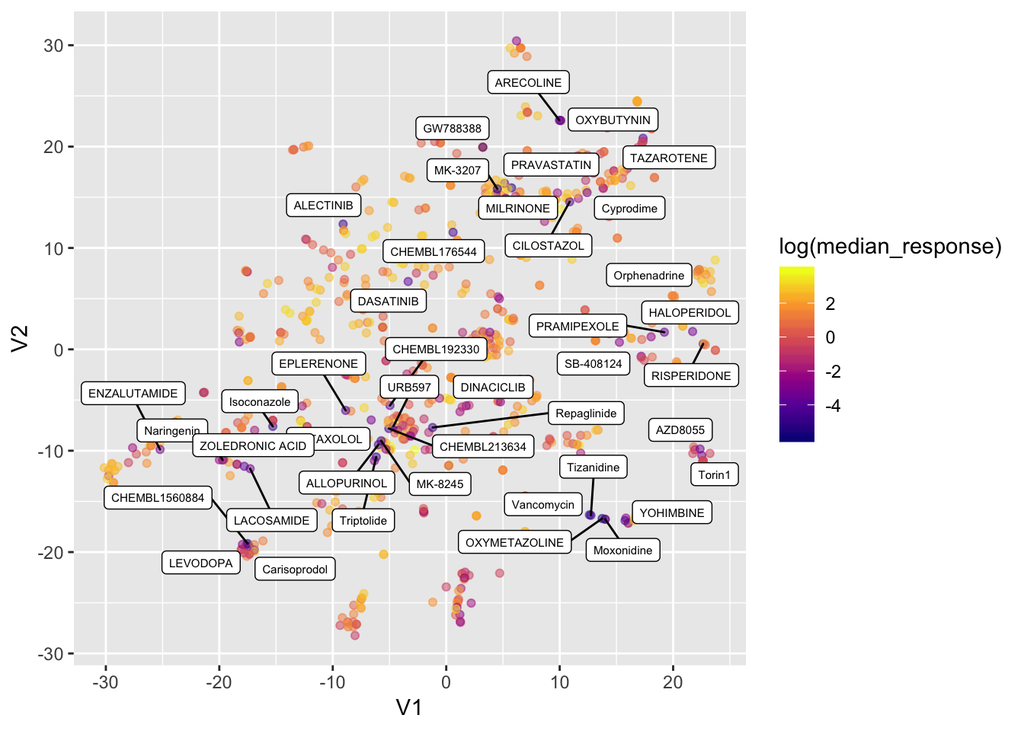

```r
ggplot(foo2) + geom_point(aes(x = V1, y = V2, color = log(median_response)), alpha = 0.5) + scale_color_viridis_c(option = "C")  + ggrepel::geom_label_repel(data = foo2 %>% filter(median_response < 0.05), aes(x = V1, y = V2, label = std_name), size = 2)
```

Unsurprisingly, mTOR inhibitors like Torin1 and AZD8055 pop out, and they are pretty close to each other.

```r
mtor <- c("AZD8055", "Torin1")
DT::datatable(targets %>% filter(std_name %in% mtor))
```

|  | internal_id | hugo_gene | std_name |
| --- | --- | --- | --- |
| 1 | 104114 | MTOR | Torin1 |
| 2 | 104114 | PIK3C3 | Torin1 |
| 3 | 199126 | FKBP1A | AZD8055 |
| 4 | 199126 | MTOR | AZD8055 |

There’s an interesting cluster containing dopamine inhibitors: risperidone, pramipexol, haloperidol:

```r
dop <- c("RISPERIDONE", "PRAMIPEXOLE", "HALOPERIDOL")

DT::datatable(targets %>% filter(std_name %in% dop))
```

|  | internal_id | hugo_gene | std_name |
| --- | --- | --- | --- |
| 1 | 99354 | ADRA1A | RISPERIDONE |
| 2 | 99354 | ADRA1B | RISPERIDONE |
| 3 | 99354 | ADRA2A | RISPERIDONE |
| 4 | 99354 | ADRA2C | RISPERIDONE |
| 5 | 99354 | DRD1 | RISPERIDONE |
| 6 | 99354 | DRD2 | RISPERIDONE |
| 7 | 99354 | DRD3 | RISPERIDONE |
| 8 | 99354 | DRD4 | RISPERIDONE |
| 9 | 99354 | GLRA1 | RISPERIDONE |
| 10 | 99354 | H1F0 | RISPERIDONE |

[output cut: 25 more lines]

And another cluster containing alpha adrenergic antagonists and NISCH inhibitors.

```r
adra <- c("YOHIMBINE", "Moxonidine", "OXYMETAZOLINE", "Vancomycin", "Tizanidine")
DT::datatable(targets %>% filter(std_name %in% adra))
```

|  | internal_id | hugo_gene | std_name |
| --- | --- | --- | --- |
| 1 | 68511 | ADRA2A | OXYMETAZOLINE |
| 2 | 68511 | ADRA2C | OXYMETAZOLINE |
| 3 | 68511 | NISCH | OXYMETAZOLINE |
| 4 | 151016 | ADRA2A | Tizanidine |
| 5 | 151016 | NISCH | Tizanidine |
| 6 | 160380 | ADRA2A | Vancomycin |
| 7 | 180742 | ADORA3 | YOHIMBINE |
| 8 | 180742 | ADRA1B | YOHIMBINE |
| 9 | 180742 | ADRA1D | YOHIMBINE |
| 10 | 180742 | ADRA2A | YOHIMBINE |

[output cut: 6 more lines]

And some TDP1 inhibitors:

```r
tdp1 <- c("CHEMBL1560884", "Carisoprodol", "LEVODOPA")
DT::datatable(targets %>% filter(std_name %in% tdp1))
```

|  | internal_id | hugo_gene | std_name |
| --- | --- | --- | --- |
| 1 | 15208 | TDP1 | CHEMBL1560884 |
| 2 | 113287 | TDP1 | Carisoprodol |
| 3 | 237237 | TDP1 | LEVODOPA |

When we loosen the threshold to median IC50 < 150 nM, we start to see more clusters pop out, but it’s a bit of a mess.

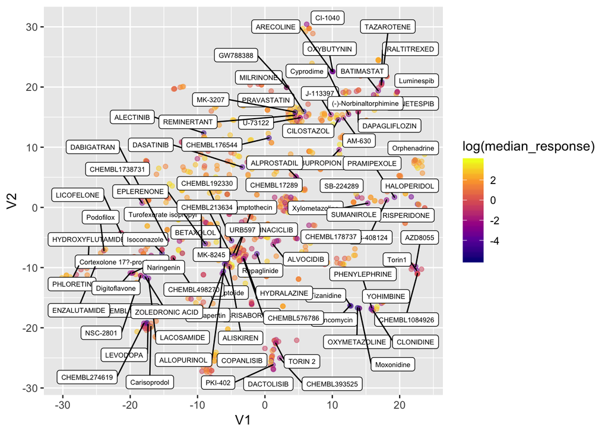

```r
ggplot(foo2) + geom_point(aes(x = V1, y = V2, color = log(median_response)), alpha = 0.5) +
  scale_color_viridis_c(option = "C")  +
  ggrepel::geom_label_repel(data = foo2 %>% filter(median_response < 0.15), aes(x = V1, y = V2, label = std_name), size = 2)
```